# Prediction Models for Weight Lifting Exercise

## Introduction

In the big push for context-aware Healthcare systems to help users stay healthy, manage their illness and support independent living, one of the areas heavily investigated is Human Actvity Recognition. Besides, enabling accurate identification of the activity performed, perhaps just as important is the ability to tell whether the activity was performed correctly.

In their paper [Qualitative Activity Recognition of Weight Lifting Exercises](http://groupware.les.inf.puc-rio.br/public/papers/2013.Velloso.QAR-WLE.pdf) by Eduardo Velloso et el., it was stated that at least 16% of all deaths could be avoided by improving one’s cardio-respiratory fitness. An effective way of doing so was regular muscle strengthening exercises, however, proper technique was paramount. Faulty execution led not only to missing the goal of building fitness but can also cause training injuries.

For this project, we aim to build on the [training](https://d396qusza40orc.cloudfront.net/predmachlearn/pml-training.csv) and [test](https://d396qusza40orc.cloudfront.net/predmachlearn/pml-testing.csv) datasets provided by Velloso et el. to create a model that will predict for any given user, his next performance of the Unilateral Dumbbell Biceps Curl. Potential application for our final model can include incorporation into a context-aware electronic personal coach or physiotherapist system that will sound premptive warning of possible injuries, suggestions for pose correction, etc.

A brief of the experiment:

- Exercises were performed by six male participants aged between 20-28 years with little weight lifting experience.
- Each participant
  - performed one set of 10 repetitions of the Unilateral Dumbbell Biceps Curl
  - in sliding windows of 0.5 second to 2.5 seconds
  - wearing three on-body wearable devices [belt, armband and glove] and interacting with a sensor-mounted 1.25kg dumbbell.

## Dataset Loading and Surveyance

The training data for this project are downloadable at:

https://d396qusza40orc.cloudfront.net/predmachlearn/pml-training.csv

The test data are available here:

https://d396qusza40orc.cloudfront.net/predmachlearn/pml-testing.csv

A couple of things were noted when checking out the training data:

1. NA values were denoted with “NA” and “#DIV/0!” strings.
2. A large proportion of the data had NAs.
3. There appears to be a redundant variable; there is skewness_roll_belt.1 and skewness_roll_belt.
4. Some variables with “pitch” in their names were misspelt, eg.
   - kurtosis_picth_belt, max_picth_belt,
   - kurtosis_picth_arm, max_picth_arm,
   - kurtosis_picth_dumbbell, max_picth_dumbbell,
   - kurtosis_picth_forearm, max_picth_forearm

## 2. Data Cleaning

To clean up the data, we converted the “NA” and “#DIV/0!” strings to R’s missing value indicator at loading. However, we will not be removing the missing data or extraneous column just yet, until we can determine the extent and the nature of the data. The misspelt variable names will also be left as it is to preserve integrity.

```r
## Given that the file is fairly large, check that the data has not already been loaded before reading it in.
if (!exists("training")) {
    training <- read.table("pml-training.csv",
                           sep = ",",
                           header = TRUE,
                           stringsAsFactors = FALSE,
                           na.strings=c("NA", "#DIV/0!"))

    ## Converting the classe variable (our outcome) to a factor variable.
    training$classe <- factor(training$classe)
}

if (!exists("testing")) {
    testing <- read.table("pml-testing.csv",
                          sep = ",",
                          header = TRUE,
                          stringsAsFactors = FALSE,
                          na.strings=c("NA", "#DIV/0!"))
}
```

## 3. Exploratory Data Analysis

An initial scope of the training data gave the impression that it has large swatches of NAs, possibly with entire rows or columns that have only NA values. Possible courses of action include:

- removing NA-only rows
- excluding NA-only columns
- imputing NA values with preProcess(.., method=“knnImpute”)
- standardizing NA values with BoxCox transformations using preProcess(.., method=c(“BoxCox”)).

However, to pick the most appropriate option requires us to know the extent of the missingness.

```r
## Check if there are observations that do not have NA values.
completeCasesCount <- sum(complete.cases(training))
completeCasesCount
```

```
## [1] 0
```

```r
## Check if there are observations that are entirely NAs for the sensor reading columns.
naRows <- which(rowSums(is.na(training[, -c(1:7, 160)])) == 152)
naRows
```

```
## integer(0)
```

```r
## Generate a table listing the number of columns with various percentages of NA.
nobs <- nrow(training)
naPercentageTally <- apply(training, 2, function(col) round(sum(is.na(col))/nobs, 2))
table(naPercentageTally)
```

```
## naPercentageTally
##    0 0.98    1
##   60   94    6
```

As shown, 6 columns are entirely NAs, 94 columns are 98% NAs and just 60 are properly filled with data. But a quick scan tells us that columns that are either entirely or almost entirely NAs are the derived sensor variables. Imputation and transformations are not required since these are possibly aggregate values calculated for an associated sliding time window.

In this case, we should be able to exclude these variables and rely on our raw sensor data for building our model. This, in my opinion, would be a cleaner way to build our model since the raw sensor readings and the derived values are most certainly highly correlated. However, there are serious misgiving building a model with less than half the feature set and we should monitor for abnormalities.

## 4. Feature Selection

Therefore, the pertinent features for our model can be narrowed down by:  
1) Removing irrelevant columns in the form of user- and time-related variables. This stamps from the assumption that our prediction model will be incorporated into an exercise feedback system. Such systems are unlikely to be user or time specific, thus the exclusion.

2. Removing columns that are entirely or almost entirely NAs.
3. Removing zero covariates, if any.

```r
## Remove the user and time related variables,
training <- training[, -c(1:7)]
dim(training)
```

```
## [1] 19622   153
```

```r
## Remove columns that are more than 95% NAs.
nearlyEmptyCols <- which(apply(training, 2, function(col) sum(is.na(col))/nrow(training) > 0.95))
training <- training[, -nearlyEmptyCols]
dim(training)
```

```
## [1] 19622    53
```

```r
nzv <- nearZeroVar(training, saveMetrics=TRUE)
nzv
```

```
##                      freqRatio percentUnique zeroVar   nzv
## roll_belt             1.101904     6.7781062   FALSE FALSE
## pitch_belt            1.036082     9.3772296   FALSE FALSE
## yaw_belt              1.058480     9.9734991   FALSE FALSE
## total_accel_belt      1.063160     0.1477933   FALSE FALSE
## gyros_belt_x          1.058651     0.7134849   FALSE FALSE
## gyros_belt_y          1.144000     0.3516461   FALSE FALSE
## gyros_belt_z          1.066214     0.8612782   FALSE FALSE
## accel_belt_x          1.055412     0.8357966   FALSE FALSE
## accel_belt_y          1.113725     0.7287738   FALSE FALSE
## accel_belt_z          1.078767     1.5237998   FALSE FALSE
## magnet_belt_x         1.090141     1.6664968   FALSE FALSE
## magnet_belt_y         1.099688     1.5187035   FALSE FALSE
## magnet_belt_z         1.006369     2.3290184   FALSE FALSE
## roll_arm             52.338462    13.5256345   FALSE FALSE
## pitch_arm            87.256410    15.7323412   FALSE FALSE
## yaw_arm              33.029126    14.6570176   FALSE FALSE
## total_accel_arm       1.024526     0.3363572   FALSE FALSE
## gyros_arm_x           1.015504     3.2769341   FALSE FALSE
## gyros_arm_y           1.454369     1.9162165   FALSE FALSE
## gyros_arm_z           1.110687     1.2638875   FALSE FALSE
## accel_arm_x           1.017341     3.9598410   FALSE FALSE
## accel_arm_y           1.140187     2.7367241   FALSE FALSE
## accel_arm_z           1.128000     4.0362858   FALSE FALSE
## magnet_arm_x          1.000000     6.8239731   FALSE FALSE
## magnet_arm_y          1.056818     4.4439914   FALSE FALSE
## magnet_arm_z          1.036364     6.4468454   FALSE FALSE
## roll_dumbbell         1.022388    84.2065029   FALSE FALSE
## pitch_dumbbell        2.277372    81.7449801   FALSE FALSE
## yaw_dumbbell          1.132231    83.4828254   FALSE FALSE
## total_accel_dumbbell  1.072634     0.2191418   FALSE FALSE
## gyros_dumbbell_x      1.003268     1.2282132   FALSE FALSE
## gyros_dumbbell_y      1.264957     1.4167771   FALSE FALSE
## gyros_dumbbell_z      1.060100     1.0498420   FALSE FALSE
## accel_dumbbell_x      1.018018     2.1659362   FALSE FALSE
## accel_dumbbell_y      1.053061     2.3748853   FALSE FALSE
## accel_dumbbell_z      1.133333     2.0894914   FALSE FALSE
## magnet_dumbbell_x     1.098266     5.7486495   FALSE FALSE
## magnet_dumbbell_y     1.197740     4.3012945   FALSE FALSE
## magnet_dumbbell_z     1.020833     3.4451126   FALSE FALSE
## roll_forearm         11.589286    11.0895933   FALSE FALSE
## pitch_forearm        65.983051    14.8557741   FALSE FALSE
## yaw_forearm          15.322835    10.1467740   FALSE FALSE
## total_accel_forearm   1.128928     0.3567424   FALSE FALSE
## gyros_forearm_x       1.059273     1.5187035   FALSE FALSE
## gyros_forearm_y       1.036554     3.7763735   FALSE FALSE
## gyros_forearm_z       1.122917     1.5645704   FALSE FALSE
## accel_forearm_x       1.126437     4.0464784   FALSE FALSE
## accel_forearm_y       1.059406     5.1116094   FALSE FALSE
## accel_forearm_z       1.006250     2.9558659   FALSE FALSE
## magnet_forearm_x      1.012346     7.7667924   FALSE FALSE
## magnet_forearm_y      1.246914     9.5403119   FALSE FALSE
## magnet_forearm_z      1.000000     8.5771073   FALSE FALSE
## classe                1.469581     0.0254816   FALSE FALSE
```

Since the nearZeroVar() test did not throw up any zero variance predictors, we ultimately end up with datasets with 53 columns each.

## 5. Cross Validation

To facilitate cross validation, we will be splitting our training data further into 3 subsets: - training (60%) - testing (20%) - validation (20%)

The testing data will be held out for testing with our final model.

```r
set.seed(2015)
## Split the training dataset into training(60%), test(20%) and validation(20%) sets.
trainIdx <- createDataPartition(training$classe, p=0.6, list=FALSE)
training.train <- training[trainIdx, ]              ## 60% of training data

training.test <- training[-trainIdx, ]              ## 40% of training data
## Again split the 40% dataset into halves.
testIdx <- createDataPartition(training.test$classe, p=0.5, list=FALSE)
training.validate <- training.test[-testIdx, ]      ## 20%
training.test <- training.test[testIdx, ]           ## 20%

dim(training.train); dim(training.test); dim(training.validate)
```

```
## [1] 11776    53
```

```
## [1] 3923   53
```

```
## [1] 3923   53
```

## 6. Model Building

The options available to us are: random forests, rpart, bagging, boosting, linear model, general linear model and Naive Bayes. However, given the nonlinear nature of the data, I have elected to use rpart and random forests. The former choice was chosen to enable a quick graphical look at how the variables are related as well as generate a list of important variables. A further attempt at boosting with the caret package was abandoned after several tries as the program never seemed to complete.

### 6.1 Building a Decision Tree Model

```r
set.seed(2015)
ctrl <- trainControl(method = "cv", number=5)
rpartModel <- train(classe ~ .,
                    data=training.train,
                    method="rpart",
                    trControl=ctrl)
rpartModel
```

```
## CART
##
## 11776 samples
##    52 predictor
##     5 classes: 'A', 'B', 'C', 'D', 'E'
##
## No pre-processing
## Resampling: Cross-Validated (5 fold)
##
## Summary of sample sizes: 9421, 9421, 9421, 9421, 9420
##
## Resampling results across tuning parameters:
##
##   cp          Accuracy   Kappa       Accuracy SD  Kappa SD
##   0.03737542  0.5037353  0.35836604  0.01435232   0.01310930
##   0.06098719  0.3925809  0.16897944  0.05680550   0.09606366
##   0.11532985  0.3155533  0.04757677  0.04276130   0.06522856
##
## Accuracy was used to select the optimal model using  the largest value.
## The final value used for the model was cp = 0.03737542.
```

```r
modelVarImp <- varImp(rpartModel)
modelVarImp
```

```
## rpart variable importance
##
##   only 20 most important variables shown (out of 52)
##
##                   Overall
## pitch_forearm      100.00
## roll_forearm        76.89
## roll_belt           71.29
## magnet_dumbbell_y   50.78
## accel_belt_z        44.44
## magnet_belt_y       42.55
## yaw_belt            41.35
## magnet_dumbbell_z   36.94
## total_accel_belt    36.88
## magnet_arm_x        27.33
## accel_arm_x         25.57
## roll_dumbbell       18.66
## roll_arm            16.37
## accel_dumbbell_y    15.19
## gyros_arm_z          0.00
## gyros_dumbbell_z     0.00
## magnet_arm_y         0.00
## gyros_belt_z         0.00
## accel_forearm_x      0.00
## yaw_dumbbell         0.00
```

In this first iteration of our classification decision tree model, accuracy is unsatisfactory at only about 51% after 5-fold cross validation. However, we have generated and identified a list of important variables (ie. importance > 0.00), which will hopefully lead to much better accuracy for our second iteration.

```r
## Build iteration 2 of the rpart model base on list of important variables identified.
#formulaStr <- paste("classe ~", paste(rownames(modelVarImp$importance)[modelVarImp$importance > 0], collapse="+"))
rpartModel <- train(classe ~ accel_arm_x + accel_belt_z + accel_dumbbell_y + magnet_arm_x + magnet_belt_y +
                    magnet_dumbbell_y + magnet_dumbbell_z + pitch_forearm + roll_arm + roll_belt + roll_dumbbell +
                    roll_forearm+total_accel_belt + yaw_belt,
                    data=training.train,
                    method="rpart",
                    trControl=ctrl)
rpartModel
```

[output not shown]

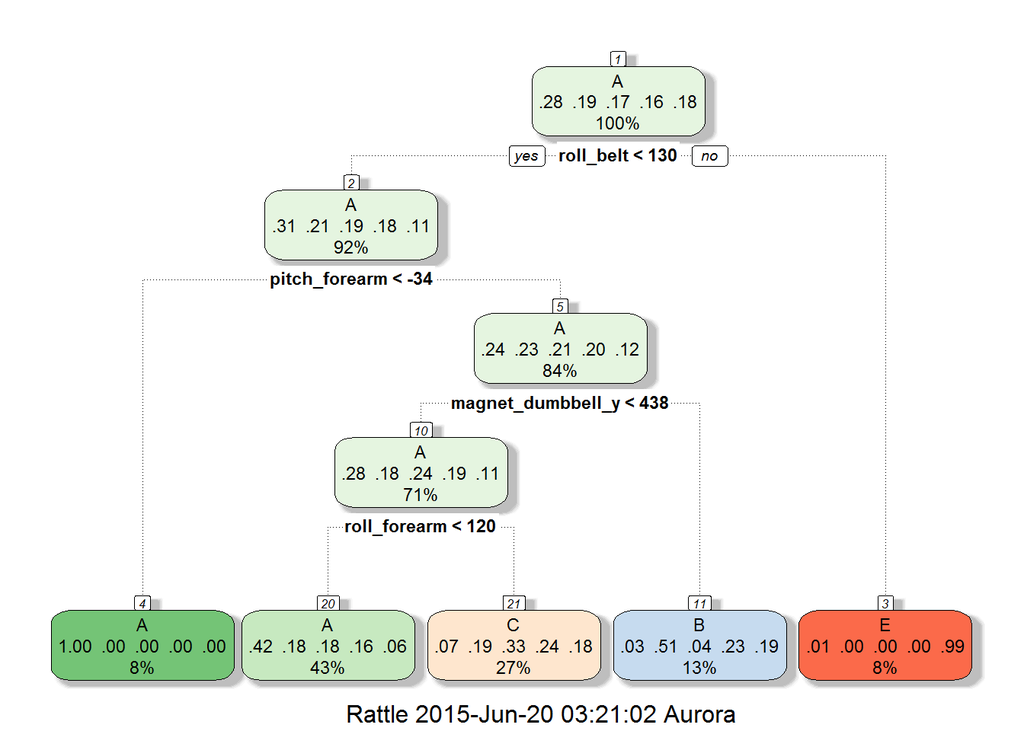

```r
fancyRpartPlot(rpartModel$finalModel)
```

Removing variables that are of zero importance did improve the model’s accuracy but only by a negligible 1%. It is also noted that there is no leaf for Class D in the RpartPlot both before and after removing variables with zero importance. This is going to pose a problem since an entire class is unrepresented in the decision tree. Nevertheless, out of curiosity, we will proceed to use the model to predict for observations in the test and validation subsets.

```r
## Predicting with test subset.
modelPredictions <- predict(rpartModel, newdata=training.test)
cmatrix <- confusionMatrix(training.test$classe, modelPredictions)
cmatrix
```

```
## Confusion Matrix and Statistics
##
##           Reference
## Prediction    A    B    C    D    E
##          A 1008   20   85    0    3
##          B  328  249  182    0    0
##          C  315   22  347    0    0
##          D  303  102  238    0    0
##          E   99   98  182    0  342
##
## Overall Statistics
##
##                Accuracy : 0.496
##                  95% CI : (0.4803, 0.5118)
##     No Information Rate : 0.5233
##     P-Value [Acc > NIR] : 0.9997
##
##                   Kappa : 0.3411
##  Mcnemar's Test P-Value : NA
##
## Statistics by Class:
##
##                      Class: A Class: B Class: C Class: D Class: E
## Sensitivity            0.4910  0.50713  0.33559       NA  0.99130
## Specificity            0.9422  0.85140  0.88335   0.8361  0.89407
## Pos Pred Value         0.9032  0.32806  0.50731       NA  0.47434
## Neg Pred Value         0.6277  0.92351  0.78790       NA  0.99906
## Prevalence             0.5233  0.12516  0.26357   0.0000  0.08794
## Detection Rate         0.2569  0.06347  0.08845   0.0000  0.08718
## Detection Prevalence   0.2845  0.19347  0.17436   0.1639  0.18379
## Balanced Accuracy      0.7166  0.67926  0.60947       NA  0.94269
```

```r
## Predicting with validation subset.
modelPredictions <- predict(rpartModel, newdata=training.validate)
cmatrix <- confusionMatrix(training.validate$classe, modelPredictions)
cmatrix
```

```
## Confusion Matrix and Statistics
##
##           Reference
## Prediction   A   B   C   D   E
##          A 994  15 104   0   3
##          B 292 260 207   0   0
##          C 324  22 338   0   0
##          D 290 115 238   0   0
##          E  98  98 216   0 309
##
## Overall Statistics
##
##                Accuracy : 0.4846
##                  95% CI : (0.4688, 0.5004)
##     No Information Rate : 0.5093
##     P-Value [Acc > NIR] : 0.9991
##
##                   Kappa : 0.3274
##  Mcnemar's Test P-Value : NA
##
## Statistics by Class:
##
##                      Class: A Class: B Class: C Class: D Class: E
## Sensitivity            0.4975  0.50980  0.30644       NA  0.99038
## Specificity            0.9366  0.85379  0.87730   0.8361  0.88590
## Pos Pred Value         0.8907  0.34256  0.49415       NA  0.42857
## Neg Pred Value         0.6423  0.92099  0.76382       NA  0.99906
## Prevalence             0.5093  0.13000  0.28116   0.0000  0.07953
## Detection Rate         0.2534  0.06628  0.08616   0.0000  0.07877
## Detection Prevalence   0.2845  0.19347  0.17436   0.1639  0.18379
## Balanced Accuracy      0.7171  0.68180  0.59187       NA  0.93814
```

Unsurprising, accuracy for the test and validation subsets of the training data continues to hover around the 50% mark.

### 6.2 Building a Random Forest Model

Here, I use the better performing randomForest package to assemble my random forest model after hitting a stonewall with caret’s random forest implementation. With an initial 10% of the training data, caret’s version took nearly half an hour to complete and at 30%, the command did not complete even after 2 hours. By comparison, the randomForest package’s implementation finished training for 60% of the training data in minutes. Cross validation was skipped since it was not required (read referenced write-up [here](https://www.stat.berkeley.edu/~breiman/RandomForests/cc_home.htm)).

```r
rfModel <- randomForest(classe ~ ., data=training.train, importance=TRUE)
rfModel
```

```
##
## Call:
##  randomForest(formula = classe ~ ., data = training.train, importance = TRUE)
##                Type of random forest: classification
##                      Number of trees: 500
## No. of variables tried at each split: 7
##
##         OOB estimate of  error rate: 0.63%
## Confusion matrix:
##      A    B    C    D    E  class.error
## A 3346    1    1    0    0 0.0005973716
## B   11 2260    8    0    0 0.0083369899
## C    0   19 2032    3    0 0.0107108082
## D    0    0   23 1906    1 0.0124352332
## E    0    0    2    5 2158 0.0032332564
```

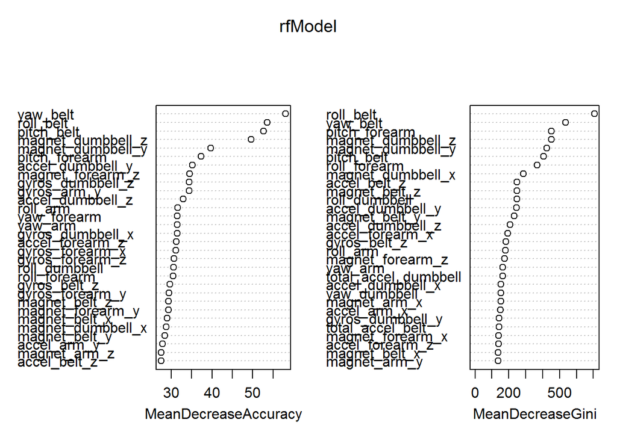

```r
varImpPlot(rfModel)
```

Given the disappointing performance from the decision tree model, it was totally unexpected that the random forest model achieve a near-perfect average of 99.4% across all classes, with an OOB (out-of-bag) error estimate of 0.63%. Here I plot random forest’s version of important variables. The MeanDecreaseAccuracy plot shows how much the model’s performance is affected without a particular variable. Hence, for a very predictive variable, we would expect a high decrease in accuracy. The MeanDecreaseGini plot measures the purity of nodes at the end of the tree and a high score in this case means the variable is important (read referenced write-up [here](http://trevorstephens.com/post/73770963794/titanic-getting-started-with-r-part-5-random)).

The model’s performance with the training data’s test and validation subsets continues to impress with accuracies in the 99%.

```r
## Predicting with test subset.
modelPredictions <- predict(rfModel, newdata=training.test)
cmatrix <- confusionMatrix(training.test$classe, modelPredictions)
cmatrix
```

```
## Confusion Matrix and Statistics
##
##           Reference
## Prediction    A    B    C    D    E
##          A 1115    1    0    0    0
##          B    6  749    4    0    0
##          C    0    3  681    0    0
##          D    0    0    9  634    0
##          E    0    0    0    5  716
##
## Overall Statistics
##
##                Accuracy : 0.9929
##                  95% CI : (0.9897, 0.9953)
##     No Information Rate : 0.2858
##     P-Value [Acc > NIR] : < 2.2e-16
##
##                   Kappa : 0.991
##  Mcnemar's Test P-Value : NA
##
## Statistics by Class:
##
##                      Class: A Class: B Class: C Class: D Class: E
## Sensitivity            0.9946   0.9947   0.9813   0.9922   1.0000
## Specificity            0.9996   0.9968   0.9991   0.9973   0.9984
## Pos Pred Value         0.9991   0.9868   0.9956   0.9860   0.9931
## Neg Pred Value         0.9979   0.9987   0.9960   0.9985   1.0000
## Prevalence             0.2858   0.1919   0.1769   0.1629   0.1825
## Detection Rate         0.2842   0.1909   0.1736   0.1616   0.1825
## Detection Prevalence   0.2845   0.1935   0.1744   0.1639   0.1838
## Balanced Accuracy      0.9971   0.9958   0.9902   0.9947   0.9992
```

```r
## Predicting with validation subset.
modelPredictions <- predict(rfModel, newdata=training.validate)
cmatrix <- confusionMatrix(training.validate$classe, modelPredictions)
cmatrix
```

```
## Confusion Matrix and Statistics
##
##           Reference
## Prediction    A    B    C    D    E
##          A 1113    0    2    0    1
##          B    3  754    2    0    0
##          C    0    4  678    2    0
##          D    0    0    5  638    0
##          E    0    0    3    2  716
##
## Overall Statistics
##
##                Accuracy : 0.9939
##                  95% CI : (0.9909, 0.9961)
##     No Information Rate : 0.2845
##     P-Value [Acc > NIR] : < 2.2e-16
##
##                   Kappa : 0.9923
##  Mcnemar's Test P-Value : NA
##
## Statistics by Class:
##
##                      Class: A Class: B Class: C Class: D Class: E
## Sensitivity            0.9973   0.9947   0.9826   0.9938   0.9986
## Specificity            0.9989   0.9984   0.9981   0.9985   0.9984
## Pos Pred Value         0.9973   0.9934   0.9912   0.9922   0.9931
## Neg Pred Value         0.9989   0.9987   0.9963   0.9988   0.9997
## Prevalence             0.2845   0.1932   0.1759   0.1637   0.1828
## Detection Rate         0.2837   0.1922   0.1728   0.1626   0.1825
## Detection Prevalence   0.2845   0.1935   0.1744   0.1639   0.1838
## Balanced Accuracy      0.9981   0.9966   0.9904   0.9961   0.9985
```

## 7. Predicting with Test Data

It is without a doubt that the chosen prediction model for use with the test data would be the random forest model. However, we will still be predicting with the decision tree model to assess it’s out of sample error rate.

```r
## Generate predictions for the test dataset using the random forest model.
rfModelPredictions <- predict(rfModel, newdata=testing)
## The output files generated are used for the project's web submissions.
pml_write_files(rfModelPredictions)

## Generate predictions for the test dataset using the decision tree model.
rpartModelPredictions <- predict(rpartModel, newdata=testing)
## Compute the confusion matrix for the predictions versus the outcome from the random forest model.
confusionMatrix(rfModelPredictions, rpartModelPredictions)
```

```
## Confusion Matrix and Statistics
##
##           Reference
## Prediction A B C D E
##          A 7 0 0 0 0
##          B 3 0 5 0 0
##          C 0 0 1 0 0
##          D 0 0 1 0 0
##          E 1 0 2 0 0
##
## Overall Statistics
##
##                Accuracy : 0.4
##                  95% CI : (0.1912, 0.6395)
##     No Information Rate : 0.55
##     P-Value [Acc > NIR] : 0.942
##
##                   Kappa : 0.2357
##  Mcnemar's Test P-Value : NA
##
## Statistics by Class:
##
##                      Class: A Class: B Class: C Class: D Class: E
## Sensitivity            0.6364       NA   0.1111       NA       NA
## Specificity            1.0000      0.6   1.0000     0.95     0.85
## Pos Pred Value         1.0000       NA   1.0000       NA       NA
## Neg Pred Value         0.6923       NA   0.5789       NA       NA
## Prevalence             0.5500      0.0   0.4500     0.00     0.00
## Detection Rate         0.3500      0.0   0.0500     0.00     0.00
## Detection Prevalence   0.3500      0.4   0.0500     0.05     0.15
## Balanced Accuracy      0.8182       NA   0.5556       NA       NA
```

## 8. Measuring Error

The following table list the performance of our 2 models. The numbers for the testing dataset was computed by hand based on the outcome of the project’s web submissions using the random forest model’s predictions.

RPart Model:

| Iteration | Remarks | Accuracy(%) | In Sample Error | Out of Sample Error |
| --- | --- | --- | --- | --- |
| 1 | training.train (53 features) | 50.4% | 49.6% | Not applicable |
| 2 | training.train (14 features) | 51.4% | 48.6% | . |
| 2 | training.test | 49.6% | 50.4% | . |
| 2 | training.validate | 48.5% | 51.5% | . |
| 2 | testing | 40% | Not applicable | 60% |

Random Forest Model:

| Iteration | Remarks | Accuracy(%) | In Sample Error | Out of Sample Error |
| --- | --- | --- | --- | --- |
| 1 | training.train (53 features) | 99.4% | 0.6% | Not applicable |
| 1 | training.test | 99.3% | 0.7% | . |
| 1 | training.validate | 99.4% | 0.6% | . |
| 1 | testing | 100% | Not applicable | 0% |

## Conclusion

Given that we are using like data to predict like, I was expecting a fairly high level of accuracy. Thus, the decision tree’s poor showing was unexpected with accuracies in the 48-51% region, even after incorporating a 5-fold preprocessing. The random forest model is the polar opposite, hitting near-perfect accuracies.

With more time, an interesting exploration would be to do feature selection using the important variables identified by the random forest model to build the decision tree model to see if its accuracy would improve. Also worth exploring is the implementation of boosting to see how well it fares compared to the random tree model as it is the other algorithm that cames highly recommended in the lectures.